# Mosier Milestone 1- Data Analysis

## EDA on Childcare Prices Dataset

### 5 September 2024

**Message** I intend to used this data as a call-to-action to employers to provide and/or subsidize childcare within their corporation.

**Target Audience** The target audience will be the decision-makers in the company. These will likely be executive level leaders with the power to make change within the company. These individuals will not be familiar with this specific data, but they are comfortable interacting with data and visualizations. As a subordinate employee in this company, it is crucial that I show I have credibility in this topic. It will also be important to show the audience that other employees want this service.

**Proposed Mediums**

1. Corporate email lobbying for time in the next board meeting for my proposal
2. Presentation, likely on PowerPoint to be presented during the board meeting
3. Interactive dashboard, likely on PowerBI to be sent to board members after presentation. This will allow me to highlight key metrics to drive the pitch home.

## Analysis

```python
# Load libraries
import pandas as pd
import numpy as np
import matplotlib.pyplot as plt
import seaborn as sns
```

```python
childcare_prices = pd.read_excel("C:/Users/kayly/OneDrive/Desktop/MSDS/DSC640/Final Project/nationaldatabaseofchildcareprices.xlsx")
childcare_prices.head()
```

|  | State_Name | State_Abbreviation | County_Name | County_FIPS_Code | StudyYear | UNR_16 | FUNR_16 | MUNR_16 | UNR_20to64 | FUNR_20to64 | ... | MFCCToddler | MFCCToddler_flag | MFCCPreschool | MFCCPreschool_flag | _75FCCInfant | _75FCCInfant_flag | _75FCCToddler | _75FCCToddler_flag | _75FCCPreschool | _75FCCPreschool_flag |
| --- | --- | --- | --- | --- | --- | --- | --- | --- | --- | --- | --- | --- | --- | --- | --- | --- | --- | --- | --- | --- | --- |
| 0 | Alabama | AL | Autauga County | 1001 | 2008 | 5.42 | 4.41 | 6.32 | 4.6 | 3.5 | ... | 83.45 | 3.0 | 81.40 | 1.0 | 97.4 | 1.0 | 97.4 | 3.0 | 95.0 | 1.0 |
| 1 | Alabama | AL | Autauga County | 1001 | 2009 | 5.93 | 5.72 | 6.11 | 4.8 | 4.6 | ... | 87.39 | 3.0 | 85.68 | 1.0 | 102.0 | 1.0 | 102.0 | 3.0 | 100.0 | 1.0 |
| 2 | Alabama | AL | Autauga County | 1001 | 2010 | 6.21 | 5.57 | 6.78 | 5.1 | 4.6 | ... | 91.33 | 3.0 | 89.96 | 1.0 | 106.6 | 1.0 | 106.6 | 3.0 | 105.0 | 1.0 |
| 3 | Alabama | AL | Autauga County | 1001 | 2011 | 7.55 | 8.13 | 7.03 | 6.2 | 6.3 | ... | 95.28 | 3.0 | 94.25 | 1.0 | 111.2 | 1.0 | 111.2 | 3.0 | 110.0 | 1.0 |
| 4 | Alabama | AL | Autauga County | 1001 | 2012 | 8.60 | 8.88 | 8.29 | 6.7 | 6.4 | ... | 99.22 | 3.0 | 98.53 | 1.0 | 115.8 | 1.0 | 115.8 | 3.0 | 115.0 | 1.0 |

5 rows × 227 columns

```python
childcare_prices.shape
```

```
(34567, 227)
```

Need to Calculate:

- Median unemployment rate of each year, by state
- Median poverty rate of all families of each year, by state
- Median poverty rate of all people of each year, by state
- Median household income of each year, by state
- Median female earnings of each year, by state
- Median male earnings of each year, by state
- Total population of each year, by state
- Median cost of childcare of each age group each year for center-based facility, by state
- Median cost of childcare of each age gorup each year for family-based facility, by state

Store all values in new dataframe indexed by state

```python
# Create a list of state names and state abbreviations
states = childcare_prices['State_Name'].unique()
state_abbrev = childcare_prices['State_Abbreviation'].unique()

# Create datatable to store median values by state, add states name and stat abbreviations as columns
medians_by_state = pd.DataFrame()
medians_by_state['State_Name'] = states
medians_by_state['State_Abbreviation'] = state_abbrev
medians_by_state.set_index('State_Name', inplace=True)

medians_by_state.head()
```

| State_Name | State_Abbreviation |
| --- | --- |
| Alabama | AL |
| Alaska | AK |
| Arizona | AZ |
| Arkansas | AR |
| California | CA |

```python
# Find median unemployment rate of each year by state
median_unemployment = childcare_prices.groupby(['State_Name', 'StudyYear'])['UNR_16'].median()

# Create dataframe of median unemployment and set the index to state name
median_unemployment = pd.DataFrame(median_unemployment)
median_unemployment.reset_index(inplace=True)
median_unemployment.set_index('State_Name', inplace=True)

# Merge two dataframes on State Name
medians_by_state= pd.merge(medians_by_state, median_unemployment, on='State_Name', how='outer')
medians_by_state
```

| State_Name | State_Abbreviation | StudyYear | UNR_16 |
| --- | --- | --- | --- |
| Alabama | AL | 2008 | 7.06 |
| Alabama | AL | 2009 | 8.17 |
| Alabama | AL | 2010 | 9.51 |
| Alabama | AL | 2011 | 10.24 |
| Alabama | AL | 2012 | 11.00 |
| ... | ... | ... | ... |
| Wyoming | WY | 2014 | 4.30 |
| Wyoming | WY | 2015 | 4.40 |
| Wyoming | WY | 2016 | 4.51 |
| Wyoming | WY | 2017 | 4.60 |
| Wyoming | WY | 2018 | 4.34 |

561 rows × 3 columns

```python
columns_needed = ['PR_F', 'PR_P', 'MHI', 'FME', 'MME', 'TotalPop', 'MCSA','MCInfant', 'MCToddler', 'MCPreschool',
                  'MFCCSA','MFCCInfant', 'MFCCToddler', 'MFCCPreschool']

for column in columns_needed:
    # Find median of each value for each year by state
    column_data = childcare_prices.groupby(['State_Name', 'StudyYear'])[column].median()

    # Create dataframe of column and set the index to state name
    column_df = pd.DataFrame(column_data)
    column_df.reset_index(inplace=True)
    column_df.set_index('State_Name', inplace=True)

    # Merge two dataframes on State Name
    medians_by_state = pd.merge(medians_by_state, column_df, on=['State_Name','StudyYear'], how='outer')

medians_by_state.reset_index(inplace=True)
medians_by_state
```

|  | State_Name | State_Abbreviation | StudyYear | UNR_16 | PR_F | PR_P | MHI | FME | MME | TotalPop | MCSA | MCInfant | MCToddler | MCPreschool | MFCCSA | MFCCInfant | MFCCToddler | MFCCPreschool |
| --- | --- | --- | --- | --- | --- | --- | --- | --- | --- | --- | --- | --- | --- | --- | --- | --- | --- | --- |
| 0 | Alabama | AL | 2008 | 7.06 | 13.9 | 18.1 | 34952.33 | 17938.0 | 30016.11 | 34635.0 | 83.76 | 98.77 | 98.77 | 85.92 | 81.40 | 83.45 | 83.45 | 81.40 |
| 1 | Alabama | AL | 2009 | 8.17 | 14.0 | 18.1 | 35137.00 | 18225.0 | 29594.00 | 34704.0 | 86.17 | 100.11 | 100.11 | 87.89 | 85.68 | 87.39 | 87.39 | 85.68 |
| 2 | Alabama | AL | 2010 | 9.51 | 14.7 | 18.7 | 36077.00 | 18879.0 | 29589.00 | 34579.0 | 88.58 | 101.44 | 101.44 | 90.13 | 89.96 | 91.33 | 91.33 | 89.96 |
| 3 | Alabama | AL | 2011 | 10.24 | 15.4 | 19.7 | 37161.00 | 19989.0 | 30288.00 | 34375.0 | 90.99 | 102.78 | 102.78 | 92.37 | 94.25 | 95.28 | 95.28 | 94.25 |
| 4 | Alabama | AL | 2012 | 11.00 | 15.4 | 19.8 | 37059.00 | 20084.0 | 30829.00 | 34228.0 | 93.10 | 104.11 | 104.11 | 94.61 | 94.79 | 96.82 | 96.82 | 94.79 |
| ... | ... | ... | ... | ... | ... | ... | ... | ... | ... | ... | ... | ... | ... | ... | ... | ... | ... | ... |
| 556 | Wyoming | WY | 2014 | 4.30 | 7.4 | 10.5 | 56318.00 | 22221.0 | 40721.00 | 15795.0 | 95.61 | 154.38 | 126.18 | 129.91 | 117.20 | 114.72 | 114.72 | 115.57 |
| 557 | Wyoming | WY | 2015 | 4.40 | 7.5 | 10.7 | 56569.00 | 21941.0 | 40851.00 | 15739.0 | 100.68 | 149.12 | 126.18 | 126.18 | 117.82 | 117.82 | 117.82 | 117.82 |
| 558 | Wyoming | WY | 2016 | 4.51 | 7.5 | 11.0 | 55640.00 | 21942.0 | 40254.00 | 15696.0 | 105.67 | 143.14 | 125.78 | 121.87 | 116.86 | 122.54 | 119.27 | 118.45 |
| 559 | Wyoming | WY | 2017 | 4.60 | 7.5 | 10.5 | 57644.00 | 23761.0 | 40395.00 | 15689.0 | 110.47 | 136.87 | 125.14 | 117.32 | 114.49 | 125.74 | 119.26 | 117.63 |
| 560 | Wyoming | WY | 2018 | 4.34 | 8.0 | 11.6 | 58521.00 | 24679.0 | 43136.00 | 15477.0 | 115.25 | 137.57 | 124.13 | 112.21 | 111.11 | 127.99 | 118.27 | 115.82 |

561 rows × 18 columns

```python
# Find number of missing values
medians_by_state.isna().sum()
```

```
State_Name              0
State_Abbreviation      0
StudyYear               0
UNR_16                  0
PR_F                    0
PR_P                    0
MHI                     0
FME                     0
MME                     0
TotalPop                0
MCSA                  173
MCInfant              173
MCToddler             173
MCPreschool           173
MFCCSA                180
MFCCInfant            180
MFCCToddler           180
MFCCPreschool         180
dtype: int64
```

```python
medians_by_state.to_csv('medians_by_state.csv', index=False)
```

## Exploratory Visualizations

```python
years = medians_by_state['StudyYear'].unique()
years
```

```
array([2008, 2009, 2010, 2011, 2012, 2013, 2014, 2015, 2016, 2017, 2018],
      dtype=int64)
```

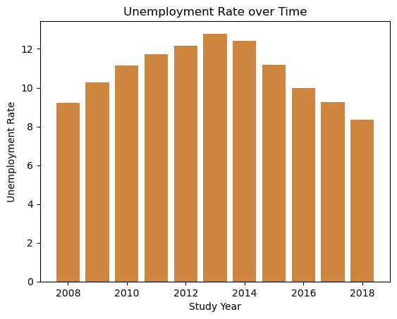

```python
# Plot unemployment rate for each year
plt.bar(x=medians_by_state['StudyYear'], height=medians_by_state['UNR_16'],color='peru')
plt.xlabel('Study Year')
plt.ylabel('Unemployment Rate')
plt.title('Unemployment Rate over Time')
plt.show()
```

The overall employment rate decreased from 2013 to 2018, with a significant reduction in unemployment rate by 2018. It would be interesting to see how childcare cost has changed since then.

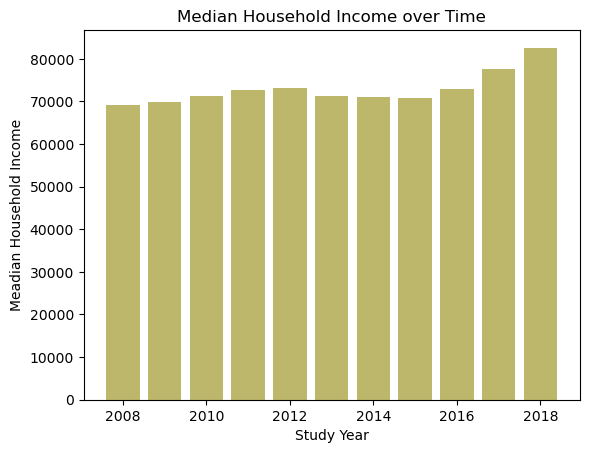

```python
# Plot median household income
plt.bar(x=medians_by_state['StudyYear'], height=medians_by_state['MHI'], color='darkkhaki')
plt.xlabel('Study Year')
plt.ylabel('Meadian Household Income')
plt.title('Median Household Income over Time')
plt.show()
```

Over the 10 years of the study, median household income only increased about 10,000 dollars. Most of that increase was observed from 2015 to 2018; the same years unemployment dropped the most.

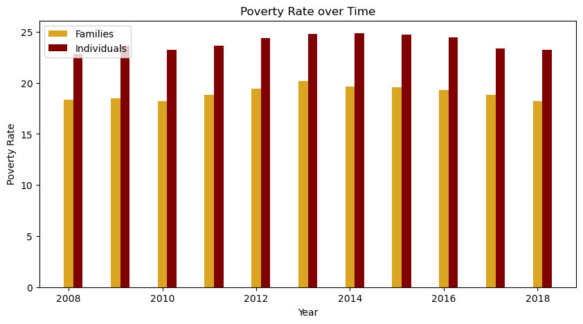

```python
# Plot grouped bar plot of median poverty rates for individuals and families
x = medians_by_state['StudyYear']
y1 = medians_by_state['PR_F']
y2 = medians_by_state['PR_P']
width=0.2

# Plot data
plt.figure(figsize=(10,5))
plt.bar(x, y1, width, color='goldenrod')
plt.bar(x+0.2, y2, width, color='maroon')
plt.legend(['Families', 'Individuals'], loc='upper left')
plt.xlabel('Year')
plt.ylabel('Poverty Rate')
plt.title('Poverty Rate over Time')
plt.show()
```

Throughout all years, poverty rate of individuals was higher than for families. For both groups, poverty rates were the highest in 2013- during peak unemployment.

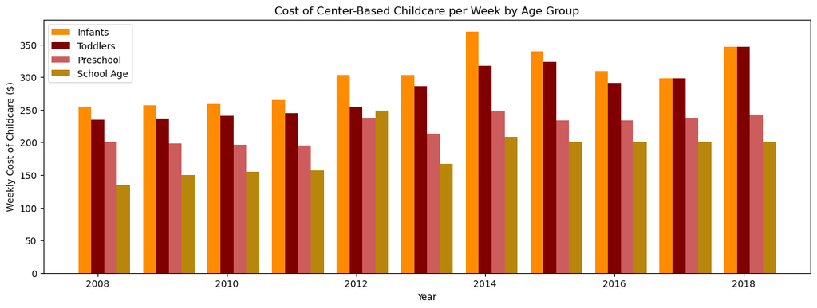

```python
# Plot grouped bar plot of median cost of center-based childcare per week by age group
# create data
x = medians_by_state['StudyYear']
y1 = medians_by_state['MCInfant']
y2 = medians_by_state['MCToddler']
y3 = medians_by_state['MCPreschool']
y4 = medians_by_state['MCSA']
width = 0.2

# plot data in grouped manner of bar type
plt.figure(figsize=(15,5))
plt.bar(x-0.2, y1, width, color='darkorange')
plt.bar(x, y2, width, color='maroon')
plt.bar(x+0.2, y3, width, color='indianred')
plt.bar(x+0.4, y4, width, color='darkgoldenrod')
plt.legend(['Infants', 'Toddlers', 'Preschool', 'School Age'],loc='upper left')
plt.xlabel('Year')
plt.ylabel('Weekly Cost of Childcare ($)')
plt.title('Cost of Center-Based Childcare per Week by Age Group')
plt.show()
```

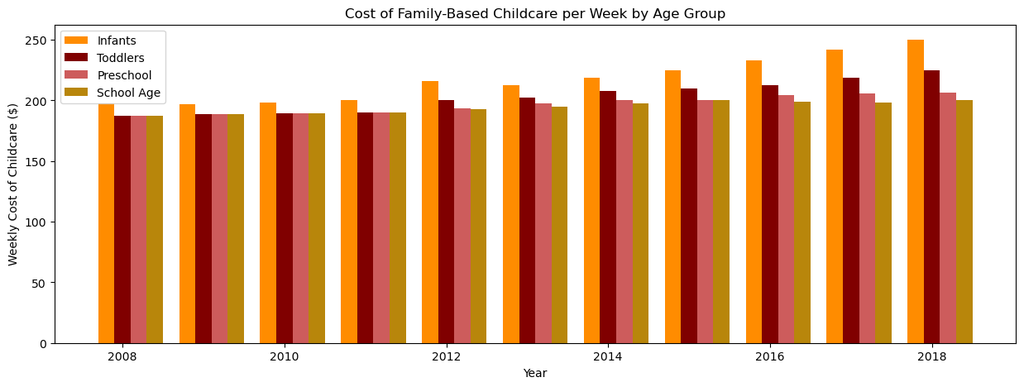

```python
# Plot grouped bar plot of median cost of center-based childcare per week by age group
# create data
x = medians_by_state['StudyYear']
y1 = medians_by_state['MFCCInfant']
y2 = medians_by_state['MFCCToddler']
y3 = medians_by_state['MFCCPreschool']
y4 = medians_by_state['MFCCSA']
width = 0.2

# plot data in grouped manner of bar type
plt.figure(figsize=(15,5))
plt.bar(x-0.2, y1, width, color='darkorange')
plt.bar(x, y2, width, color='maroon')
plt.bar(x+0.2, y3, width, color='indianred')
plt.bar(x+0.4, y4, width, color='darkgoldenrod')
plt.legend(['Infants', 'Toddlers', 'Preschool', 'School Age'], loc='upper left')
plt.xlabel('Year')
plt.ylabel('Weekly Cost of Childcare ($)')
plt.title('Cost of Family-Based Childcare per Week by Age Group')
plt.show()
```

Family-based child care prices steadily increased across observation years. Like in center-based childcare, infant care is the most expensive.

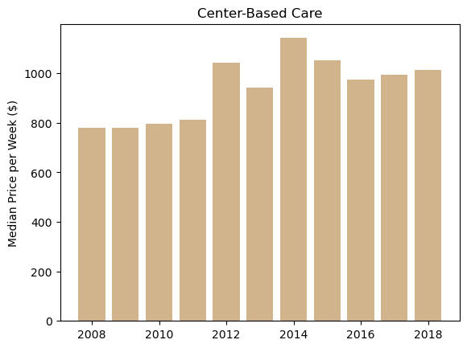

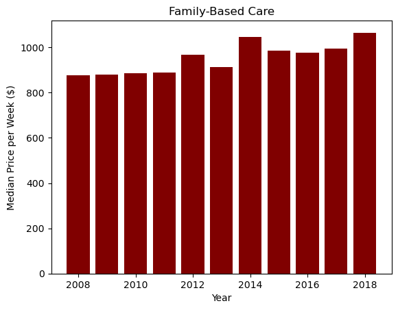

```python
# create data for center based
x = medians_by_state['StudyYear']
y1_center = medians_by_state['MCInfant']
y2_center = medians_by_state['MCToddler']
y3_center = medians_by_state['MCPreschool']
y4_center = medians_by_state['MCSA']

# plot center-based facilites in stacked bar
plt.subplot(1,1,1)
plt.bar(x, y1_center, color='tan')
plt.bar(x, y2_center, bottom=y1_center, color='tan')
plt.bar(x, y3_center, bottom=(y1_center+y2_center), color='tan')
plt.bar(x, y4_center, bottom=(y1_center+y2_center+y3_center), color='tan')
plt.title('Year')
plt.ylabel('Median Price per Week ($)')
plt.title('Center-Based Care')
plt.show()

# Create data for family based
y1_family = medians_by_state['MFCCInfant']
y2_family = medians_by_state['MFCCToddler']
y3_family = medians_by_state['MFCCPreschool']
y4_family = medians_by_state['MFCCSA']

# plot family-based facilities in stacked bar
plt.subplot(1,1,1)
plt.bar(x, y1_family, color='maroon')
plt.bar(x, y2_family, bottom=y1_center, color='maroon')
plt.bar(x, y3_family, bottom=(y1_center+y2_center), color='maroon')
plt.bar(x, y4_family, bottom=(y1_center+y2_center+y3_center), color='maroon')
plt.xlabel('Year')
plt.ylabel('Median Price per Week ($)')
plt.title('Family-Based Care')
plt.show()
```

The total cost of childcare for center-based and family-based facilites is pretty similiar over time. In 2018, family-base childcare was more expensive than center-based care.

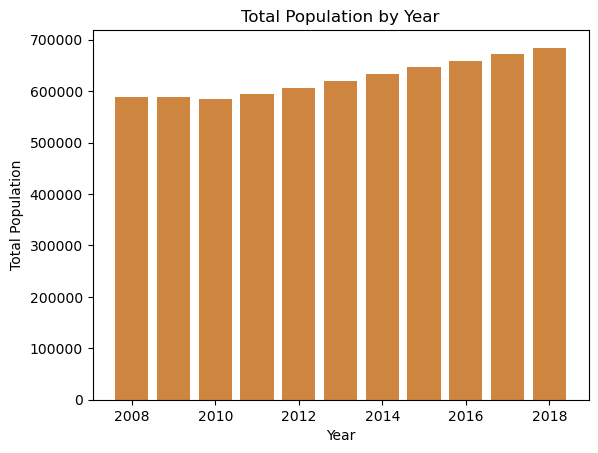

```python
# Plot total popualation as a function of time
plt.bar(medians_by_state['StudyYear'], medians_by_state['TotalPop'],color='Peru')
plt.xlabel('Year')
plt.ylabel('Total Population')
plt.title('Total Population by Year')
plt.show()
```

Population steadily increased through observation years.

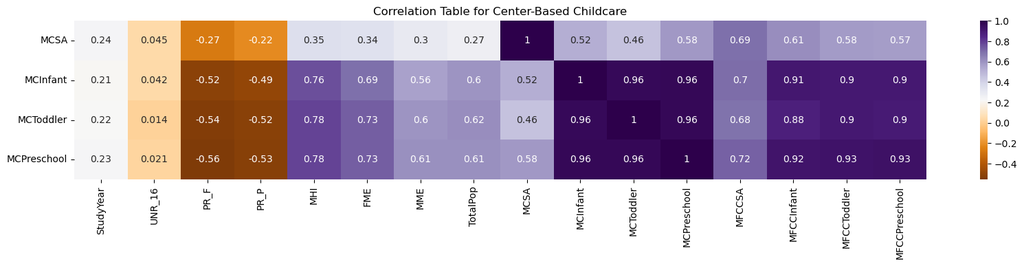

```python
columns = medians_by_state.columns
columns

# Subset dataframe
medians_subset = medians_by_state.loc[:,['StudyYear', 'UNR_16', 'PR_F',
       'PR_P', 'MHI', 'FME', 'MME', 'TotalPop', 'MCSA', 'MCInfant',
       'MCToddler', 'MCPreschool', 'MFCCSA', 'MFCCInfant', 'MFCCToddler',
       'MFCCPreschool']]

# Plot correlation table for each feature variable with Diabetes_binary
plt.figure(figsize=(20,3))
sns.heatmap(medians_subset.corr().loc[['MCSA','MCInfant', 'MCToddler', 'MCPreschool'],:], annot=True, cmap='PuOr')
plt.title('Correlation Table for Center-Based Childcare')
plt.show()
```

**Center-Based Facilities**: There are no strong relationships between cost of childcare for school aged children and any other variable. There is a strong relationship between mean houshold income and 3 of the child age care groups; infant, toddler, and preschool. There is a moderate relationship between female and male median earnings and 3 of the child age care groups: infant, toddler, and preschool.

There is also strong correlation between care-based center and family-based centers.

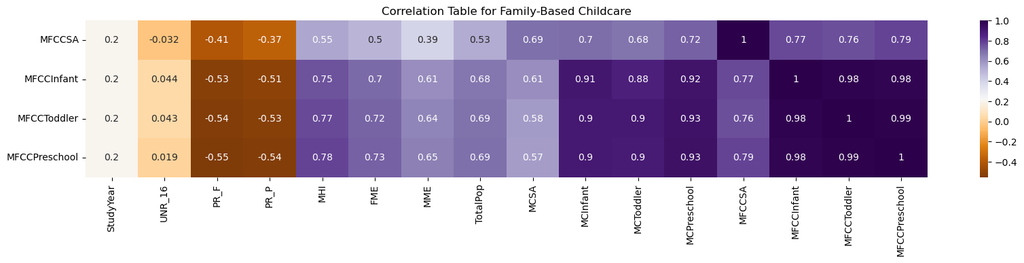

```python
# Plot correlation table for each feature variable with Diabetes_binary
plt.figure(figsize=(20,3))
sns.heatmap(medians_subset.corr().loc[['MFCCSA','MFCCInfant', 'MFCCToddler', 'MFCCPreschool'],:], annot=True, cmap='PuOr')
plt.title('Correlation Table for Family-Based Childcare')
```

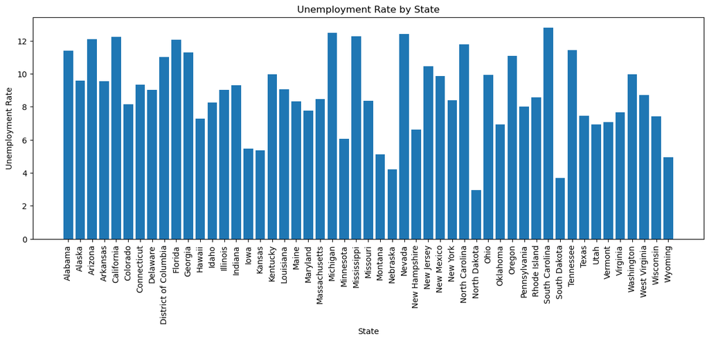

```python
# Plot unemployment rate by state
plt.figure(figsize=(15,5))
plt.bar(medians_by_state['State_Name'], medians_by_state['UNR_16'])
plt.xticks(rotation='vertical')
plt.xlabel('State')
plt.ylabel('Unemployment Rate')
plt.title('Unemployment Rate by State')
plt.show()
```

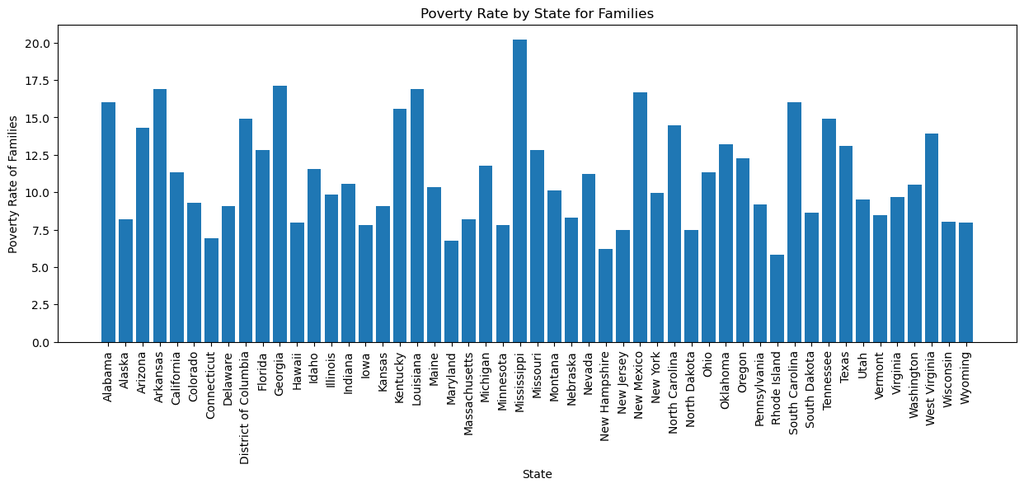

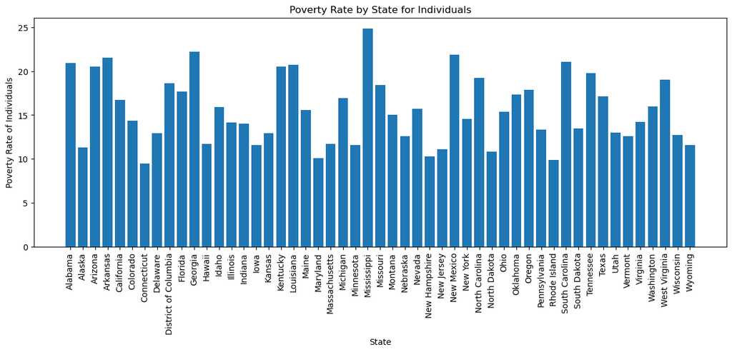

```python
# Plot poverty rate by state
plt.figure(figsize=(15,5))
plt.bar(medians_by_state['State_Name'], medians_by_state['PR_F'])
plt.xticks(rotation='vertical')
plt.xlabel('State')
plt.ylabel('Poverty Rate of Families')
plt.title('Poverty Rate by State for Families')
plt.show()

plt.figure(figsize=(15,5))
plt.bar(medians_by_state['State_Name'], medians_by_state['PR_P'])
plt.xticks(rotation='vertical')
plt.xlabel('State')
plt.ylabel('Poverty Rate of Individuals')
plt.title('Poverty Rate by State for Individuals')
plt.show()
```

```python
medians_by_state.set_index(['State_Name'], inplace=True)
medians_by_state.sort_values('PR_F', ascending=False)
medians_by_state
```

| State_Name | State_Abbreviation | StudyYear | UNR_16 | PR_F | PR_P | MHI | FME | MME | TotalPop | MCSA | MCInfant | MCToddler | MCPreschool | MFCCSA | MFCCInfant | MFCCToddler | MFCCPreschool |
| --- | --- | --- | --- | --- | --- | --- | --- | --- | --- | --- | --- | --- | --- | --- | --- | --- | --- |
| Alabama | AL | 2008 | 7.06 | 13.9 | 18.1 | 34952.33 | 17938.0 | 30016.11 | 34635.0 | 83.76 | 98.77 | 98.77 | 85.92 | 81.40 | 83.45 | 83.45 | 81.40 |
| Alabama | AL | 2009 | 8.17 | 14.0 | 18.1 | 35137.00 | 18225.0 | 29594.00 | 34704.0 | 86.17 | 100.11 | 100.11 | 87.89 | 85.68 | 87.39 | 87.39 | 85.68 |
| Alabama | AL | 2010 | 9.51 | 14.7 | 18.7 | 36077.00 | 18879.0 | 29589.00 | 34579.0 | 88.58 | 101.44 | 101.44 | 90.13 | 89.96 | 91.33 | 91.33 | 89.96 |
| Alabama | AL | 2011 | 10.24 | 15.4 | 19.7 | 37161.00 | 19989.0 | 30288.00 | 34375.0 | 90.99 | 102.78 | 102.78 | 92.37 | 94.25 | 95.28 | 95.28 | 94.25 |
| Alabama | AL | 2012 | 11.00 | 15.4 | 19.8 | 37059.00 | 20084.0 | 30829.00 | 34228.0 | 93.10 | 104.11 | 104.11 | 94.61 | 94.79 | 96.82 | 96.82 | 94.79 |
| ... | ... | ... | ... | ... | ... | ... | ... | ... | ... | ... | ... | ... | ... | ... | ... | ... | ... |
| Wyoming | WY | 2014 | 4.30 | 7.4 | 10.5 | 56318.00 | 22221.0 | 40721.00 | 15795.0 | 95.61 | 154.38 | 126.18 | 129.91 | 117.20 | 114.72 | 114.72 | 115.57 |
| Wyoming | WY | 2015 | 4.40 | 7.5 | 10.7 | 56569.00 | 21941.0 | 40851.00 | 15739.0 | 100.68 | 149.12 | 126.18 | 126.18 | 117.82 | 117.82 | 117.82 | 117.82 |
| Wyoming | WY | 2016 | 4.51 | 7.5 | 11.0 | 55640.00 | 21942.0 | 40254.00 | 15696.0 | 105.67 | 143.14 | 125.78 | 121.87 | 116.86 | 122.54 | 119.27 | 118.45 |
| Wyoming | WY | 2017 | 4.60 | 7.5 | 10.5 | 57644.00 | 23761.0 | 40395.00 | 15689.0 | 110.47 | 136.87 | 125.14 | 117.32 | 114.49 | 125.74 | 119.26 | 117.63 |
| Wyoming | WY | 2018 | 4.34 | 8.0 | 11.6 | 58521.00 | 24679.0 | 43136.00 | 15477.0 | 115.25 | 137.57 | 124.13 | 112.21 | 111.11 | 127.99 | 118.27 | 115.82 |

561 rows × 17 columns

## Focus on Arkansas

```python
arkansas_prices = childcare_prices.loc[childcare_prices['State_Name'] == 'Arkansas']
arkansas_prices
```

|  | State_Name | State_Abbreviation | County_Name | County_FIPS_Code | StudyYear | UNR_16 | FUNR_16 | MUNR_16 | UNR_20to64 | FUNR_20to64 | ... | MFCCToddler | MFCCToddler_flag | MFCCPreschool | MFCCPreschool_flag | _75FCCInfant | _75FCCInfant_flag | _75FCCToddler | _75FCCToddler_flag | _75FCCPreschool | _75FCCPreschool_flag |
| --- | --- | --- | --- | --- | --- | --- | --- | --- | --- | --- | --- | --- | --- | --- | --- | --- | --- | --- | --- | --- | --- |
| 1220 | Arkansas | AR | Arkansas County | 5001 | 2008 | 7.38 | 6.80 | 7.93 | 6.51 | 6.94 | ... | NaN | NaN | NaN | NaN | NaN | NaN | NaN | NaN | NaN | NaN |
| 1221 | Arkansas | AR | Arkansas County | 5001 | 2009 | 7.95 | 7.31 | 8.51 | 7.20 | 7.40 | ... | NaN | NaN | NaN | NaN | NaN | NaN | NaN | NaN | NaN | NaN |
| 1222 | Arkansas | AR | Arkansas County | 5001 | 2010 | 7.36 | 7.32 | 7.40 | 6.40 | 6.80 | ... | NaN | NaN | NaN | NaN | NaN | NaN | NaN | NaN | NaN | NaN |
| 1223 | Arkansas | AR | Arkansas County | 5001 | 2011 | 7.59 | 7.81 | 7.39 | 6.80 | 7.50 | ... | NaN | NaN | NaN | NaN | NaN | NaN | NaN | NaN | NaN | NaN |
| 1224 | Arkansas | AR | Arkansas County | 5001 | 2012 | 7.26 | 8.27 | 6.33 | 7.00 | 8.80 | ... | NaN | NaN | NaN | NaN | NaN | NaN | NaN | NaN | NaN | NaN |
| ... | ... | ... | ... | ... | ... | ... | ... | ... | ... | ... | ... | ... | ... | ... | ... | ... | ... | ... | ... | ... | ... |
| 2040 | Arkansas | AR | Yell County | 5149 | 2014 | 8.10 | 5.64 | 10.23 | 7.30 | 4.60 | ... | 77.5 | 1.0 | 75.63 | 1.0 | 97.5 | 2.0 | 87.5 | 1.0 | 87.5 | 1.0 |
| 2041 | Arkansas | AR | Yell County | 5149 | 2015 | 8.28 | 6.98 | 9.46 | 7.30 | 5.50 | ... | 80.0 | 1.0 | 77.50 | 1.0 | 100.0 | 2.0 | 90.0 | 1.0 | 90.0 | 1.0 |
| 2042 | Arkansas | AR | Yell County | 5149 | 2016 | 6.75 | 5.62 | 7.73 | 6.40 | 5.20 | ... | 82.5 | 1.0 | 79.38 | 1.0 | 102.5 | 2.0 | 92.5 | 1.0 | 92.5 | 1.0 |
| 2043 | Arkansas | AR | Yell County | 5149 | 2017 | 6.32 | 6.21 | 6.40 | 5.80 | 5.50 | ... | 85.0 | 1.0 | 81.25 | 1.0 | 105.0 | 2.0 | 95.0 | 1.0 | 95.0 | 1.0 |
| 2044 | Arkansas | AR | Yell County | 5149 | 2018 | 5.55 | 5.64 | 5.48 | 5.10 | 5.00 | ... | 87.5 | 1.0 | 83.13 | 1.0 | 107.5 | 2.0 | 97.5 | 1.0 | 97.5 | 1.0 |

825 rows × 227 columns

```python
# Checking number of counties in Arkansas
arkansas_prices['County_Name'].nunique()
```

```
75
```

In this scenario, I will be working for Walmart which has it's corporate headquarters in Bentonville, Arkansas.

It would be useful to investigate median household income, median earnings, etc of Arkansas versus the national averages.

```python
# Find median key metrics of Arkansas vs the rest of the country
print('------Median Household Income------')
print('Country: ',medians_by_state['MHI'].median())
print('Arkansas: ',arkansas_prices['MHI'].median())

print('\n------Unemployment Rate------')
print('Country: ',medians_by_state['UNR_16'].median())
print('Arkansas: ',arkansas_prices['UNR_16'].median())

print('\n------Povert Rate of Families------')
print('Country: ',medians_by_state['PR_F'].median())
print('Arkansas: ',arkansas_prices['PR_F'].median())

print('\n------Poverty Rate of Individuals------')
print('Country: ',medians_by_state['PR_P'].median())
print('Arkansas: ',arkansas_prices['PR_P'].median())

print('\n------Female Mean Earnings------')
print('Country: ',medians_by_state['FME'].median())
print('Arkansas: ',arkansas_prices['FME'].median())

print('\n------Male Mean Earnings------')
print('Country: ',medians_by_state['MME'].median())
print('Arkansas: ',arkansas_prices['MME'].median())
```

```
------Median Household Income------
Country:  46872.0
Arkansas:  35732.0

------Unemployment Rate------
Country:  7.04
Arkansas:  8.04

------Povert Rate of Families------
Country:  9.5
Arkansas:  15.2

------Poverty Rate of Individuals------
Country:  13.81
Arkansas:  20.1

------Female Mean Earnings------
Country:  21562.0
Arkansas:  19160.0

------Male Mean Earnings------
Country:  32671.5
Arkansas:  28568.0
```

Arkansas has a lower household income and median earnings that the rest of the country. Additionally, Arkansas has a higher unemployment rate and poverty rate than the rest of the country.

```python
# Calculate median prices of center-based childcare in Arkansas versus the rest of the country
print('\n------Center-Based Childcare of School-Aged Children------')
print('Country: ',medians_by_state['MCSA'].median())
print('Arkansas: ',arkansas_prices['MCSA'].median())

print('\n------Center-Based Childcare of Infants------')
print('Country: ',medians_by_state['MCInfant'].median())
print('Arkansas: ',arkansas_prices['MCInfant'].median())

print('\n------Center-Based Childcare of Toddlers------')
print('Country: ',medians_by_state['MCToddler'].median())
print('Arkansas: ',arkansas_prices['MCToddler'].median())

print('\n------Center-Based Childcare of Preschoolers------')
print('Country: ',medians_by_state['MCPreschool'].median())
print('Arkansas: ',arkansas_prices['MCPreschool'].median())
```

```
------Center-Based Childcare of School-Aged Children------
Country:  98.325
Arkansas:  77.5

------Center-Based Childcare of Infants------
Country:  148.765
Arkansas:  97.5

------Center-Based Childcare of Toddlers------
Country:  133.235
Arkansas:  95.75

------Center-Based Childcare of Preschoolers------
Country:  123.33
Arkansas:  87.5
```

```python
# Calculate median prices of family-based childcare in Arkansas versus the rest of the country
print('\n------Family-Based Childcare of School-Aged Children------')
print('Country: ',medians_by_state['MFCCSA'].median())
print('Arkansas: ',arkansas_prices['MFCCSA'].median())

print('\n------Family-Based Childcare of Infants------')
print('Country: ',medians_by_state['MFCCInfant'].median())
print('Arkansas: ',arkansas_prices['MFCCInfant'].median())

print('\n------Family-Based Childcare of Toddlers------')
print('Country: ',medians_by_state['MFCCToddler'].median())
print('Arkansas: ',arkansas_prices['MFCCToddler'].median())

print('\n------Family-Based Childcare of Preschoolers------')
print('Country: ',medians_by_state['MFCCPreschool'].median())
print('Arkansas: ',arkansas_prices['MFCCPreschool'].median())
```

```
------Family-Based Childcare of School-Aged Children------
Country:  93.33500000000001
Arkansas:  78.75

------Family-Based Childcare of Infants------
Country:  115.38
Arkansas:  87.5

------Family-Based Childcare of Toddlers------
Country:  109.95
Arkansas:  85.0

------Family-Based Childcare of Preschoolers------
Country:  105.63
Arkansas:  81.25
```

Childcare for both center-based and family-based facilities is less expensive in Arkansas than the rest of the country.

## Focus on County

There is a large wealth gap in Arkansas. To correctly represent metrics it is important to focus on the county level

```python
# Filter for Benton and Washington counties
arkansas_counties = arkansas_prices[(arkansas_prices['County_Name'] == 'Benton County') |
                                   (arkansas_prices['County_Name'] == 'Washington County')]
arkansas_counties.head()
```

|  | State_Name | State_Abbreviation | County_Name | County_FIPS_Code | StudyYear | UNR_16 | FUNR_16 | MUNR_16 | UNR_20to64 | FUNR_20to64 | ... | MFCCToddler | MFCCToddler_flag | MFCCPreschool | MFCCPreschool_flag | _75FCCInfant | _75FCCInfant_flag | _75FCCToddler | _75FCCToddler_flag | _75FCCPreschool | _75FCCPreschool_flag |
| --- | --- | --- | --- | --- | --- | --- | --- | --- | --- | --- | --- | --- | --- | --- | --- | --- | --- | --- | --- | --- | --- |
| 1253 | Arkansas | AR | Benton County | 5007 | 2008 | 4.64 | 3.96 | 5.21 | 4.1 | 3.5 | ... | NaN | NaN | NaN | NaN | NaN | NaN | NaN | NaN | NaN | NaN |
| 1254 | Arkansas | AR | Benton County | 5007 | 2009 | 5.46 | 5.54 | 5.39 | 5.1 | 5.3 | ... | NaN | NaN | NaN | NaN | NaN | NaN | NaN | NaN | NaN | NaN |
| 1255 | Arkansas | AR | Benton County | 5007 | 2010 | 5.33 | 4.54 | 6.00 | 4.8 | 4.2 | ... | NaN | NaN | NaN | NaN | NaN | NaN | NaN | NaN | NaN | NaN |
| 1256 | Arkansas | AR | Benton County | 5007 | 2011 | 5.53 | 4.37 | 6.52 | 4.9 | 4.0 | ... | NaN | NaN | NaN | NaN | NaN | NaN | NaN | NaN | NaN | NaN |
| 1257 | Arkansas | AR | Benton County | 5007 | 2012 | 5.25 | 3.99 | 6.30 | 4.6 | 3.6 | ... | NaN | NaN | NaN | NaN | NaN | NaN | NaN | NaN | NaN | NaN |

5 rows × 227 columns

```python
# Find average male and female earnings
print('\n------Female Median Earnings------')
print('Country: ',arkansas_counties['FME'].median())

print('\n------Male Median Earnings------')
print('Country: ',arkansas_counties['MME'].median())
```

```
------Female Median Earnings------
Country:  23518.0

------Male Median Earnings------
Country:  31659.0
```

```python
median_earnings = ((23518+31659)/2)/12
median_earnings
```

```
2299.0416666666665
```

```python
# Calculate median prices of center-based childcare in Benton & Washington County
center_school_aged = arkansas_counties['MCSA'].median()
center_infant =arkansas_counties['MCInfant'].median()
center_toddler = arkansas_counties['MCToddler'].median()
center_preschool = arkansas_counties['MCPreschool'].median()

print('\n------Center-Based Childcare------')
print('School-Aged:', center_school_aged)
print('Infant:', center_infant)
print('Toddler:', center_toddler)
print('Preschool:', center_preschool)

# Calculate median prices of family-based childcare in Arkansas versus the rest of the country
family_school_aged = arkansas_counties['MFCCSA'].median()
family_infant = arkansas_counties['MFCCInfant'].median()
family_toddler = arkansas_counties['MFCCToddler'].median()
family_preschool = arkansas_counties['MFCCPreschool'].median()

print('\n------Family-Based Childcare------')
print('School-Aged:', family_school_aged)
print('Infant:', family_infant)
print('Toddler:', family_toddler)
print('Preschool:', family_preschool)
```

```
------Center-Based Childcare------
School-Aged: 100.75
Infant: 128.75
Toddler: 119.59
Preschool: 108.75

------Family-Based Childcare------
School-Aged: 86.25
Infant: 102.5
Toddler: 96.25
Preschool: 91.25
```

```python
# Calulcate median
median_price_care = sum([center_school_aged+center_infant,center_toddler+center_preschool])/4
median_price_care
```

```
114.46000000000001
```

```python
# Calculate average % spent on childcare
(median_price_care / median_earnings)*100
```

```
4.978596154194683
```

```python
# Find average cost of childcare for infants per state
```

[output not shown]